# Praca domowa - Oscary

Magdalena Mazurek

5 marca 2016

# Dane

Tweety pobrałam i zapisałam do pliku przy pomocy następującego kodu:

```r
tweets <- searchTwitter('oscar', n=100000, since='2016-02-28', until='2016-02-29', lang = 'en')
   dftweets <- twListToDF(tweets)
   write.csv(dftweets, oscar.csv)
```

Jak widać pobrałam 100000 tweet’ów tylko z zapytaniem o same oscary, tzn. `oscar`. Dodatkowo pobrałam tylko tweet’y w języku angielskim. Okazało się, że sa to tweety tylko z dwóch godzin:

```r
min(levels(dane[,6]))
```

```
## [1] "2016-02-28 22:00:50"
```

```r
max(levels(dane[,6]))
```

```
## [1] "2016-02-28 23:59:59"
```

# Statystyki

Zobaczmy, który tweet dostał najwięcej polubień.

```r
favorite<-dane[,4]
max(favorite)
```

```
## [1] 29362
```

Sprawdźmy, co to był za tweet.

```r
dane[which.max(favorite),2]
```

```
## [1] I hope I wake up to Leo winning an Oscar
## 38053 Levels: 00:00 GIVE LEO AN OSCAR #Oscars ... || @ Someone who is good at editing, pls do Halsey and Oscar Isaac.
```

Użytkownik, który dodał ten tweet jest jednym z bardziej znanych youtube’rów, więc nie dziwi ilość polubień.

Zobaczmy na pozostałe tweety i ich polubienia.

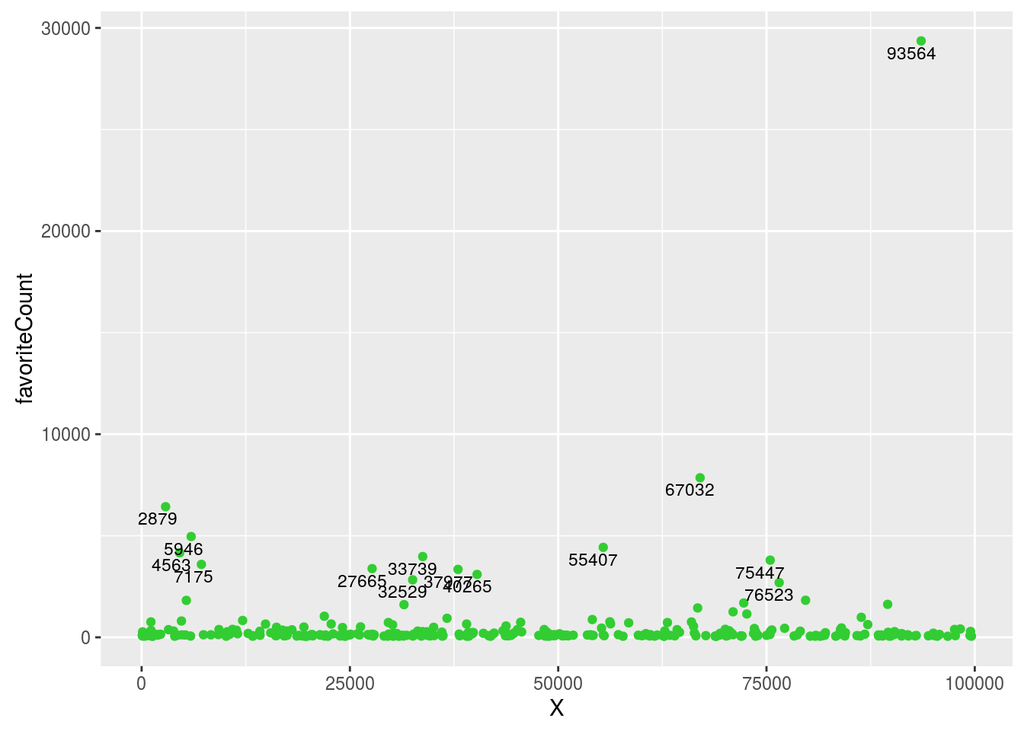

```r
ggplot(dane[dane[,4]>50,],aes(x=X,y=favoriteCount))+
   geom_point(col="limegreen",show.legend = FALSE)+
   geom_text(aes(label=ifelse(favoriteCount>2000,X,'')),hjust=0.7, vjust=1.5,size=3)
```

Widać, że są tweet’y, których liczba polubień jest bardzo wysoka. Przyjrzyjmy się ich treści.

```r
dane[which(favorite>4000),2]
```

```
## [1] I'm hiding by a bush.  So far the Oscar's are awesome https://t.co/iDcGetRl46
## [2] QUICK SPREAD THESE LEONARDO DICAPRIO OSCAR JOKES WHILE YOU STILL CAN https://t.co/BziBiZGQzN
## [3] If Leonardo DiCaprio wins an Oscar tonight, I will give $10 to everyone who retweets this.
## [4] Leo. Has. To. Win. His. Oscar.
## [5] Previous Leo roles that deserved an Oscar https://t.co/xZh826EVIy
## [6] I hope I wake up to Leo winning an Oscar
## 38053 Levels: 00:00 GIVE LEO AN OSCAR #Oscars ... || @ Someone who is good at editing, pls do Halsey and Oscar Isaac.
```

Dotyczą one aktora Leonarda Di Caprio. Zobaczmy wiec ile tweet’ów jest z nim zwiazanych.

```r
ile <- unlist(lapply(dane[,2],function(x){
   stri_count_regex(as.character(x),"[Ll][Ee][Oo]")
}))
sum(ile!=0)
```

```
## [1] 51817
```

Połowa tweet’ów dotycze Leonardo, czyli można powiedzieć, że był on ulubieńcem “internetu”. Spróbujmy dowiedzieć się czy reakcje odnośnie Leo były negatywne czy pozytywne. W tym celu wczytamy słowniki ze slowami pozytywnymi oraz negatywnymi i zliczymy dla każdego tweet’a ilość słów pozytywnych i negatywnych. Zajmiemy się tylko tymi tweet’ami, które nie były retweet’owane.

```r
slownik_neg<-read.table("/home/magda/RiBD/negative-words.txt",skip=35)
slownik_pos<-read.table("/home/magda/RiBD/positive-words.txt",skip=35)

leo<-dane[ile!=0 & dane[,14]==FALSE,1:2]

ile_pos_neg<-sapply(as.character(leo[,2]), function(y){
   tweet_slowa<-unlist(stri_extract_all_words(y))
   wydzwiek_lista<-lapply(tweet_slowa, function(z){
      if ( z %in% slownik_neg[,1] ) return(-1) else {
         if ( z %in% slownik_pos[,1] ) return(1) else return (0) }
      })
   wydzwiek<-unlist(wydzwiek_lista)
   ile<-c(sum(wydzwiek>0),sum(wydzwiek<0))
})
ile_pos_neg2<-t(as.matrix.data.frame(ile_pos_neg,dimnames=list(1:2,seq(1,length(leo[,1])))))

leo_wydzwiek<-cbind(leo,ile_pos_neg2)

ile_neu<-sum(leo_wydzwiek[,3]==leo_wydzwiek[,4])
ile_p<-sum(leo_wydzwiek[,3]>leo_wydzwiek[,4])
ile_neg<-sum(leo_wydzwiek[,3]<leo_wydzwiek[,4])

print(c(ile_neg,ile_neu,ile_p))
```

```
## [1] 1043 4932 7581
```

Okazuje się, że tweet’ów dla ktorych mamy tą samą liczbę negatywnych i pozytywnych wyrazów jest 4932, tweet’ów z większą liczbą wyrazów pozytywnych jest 7581, natomiast z większą liczbą wyrazów negatywnych jest 1043.

Teraz zobaczmy jak w czasie rozkładała sięliczba dodawanych tweet’ów. Zobaczymy liczbę tweet’ów wstawianych co sekundę.

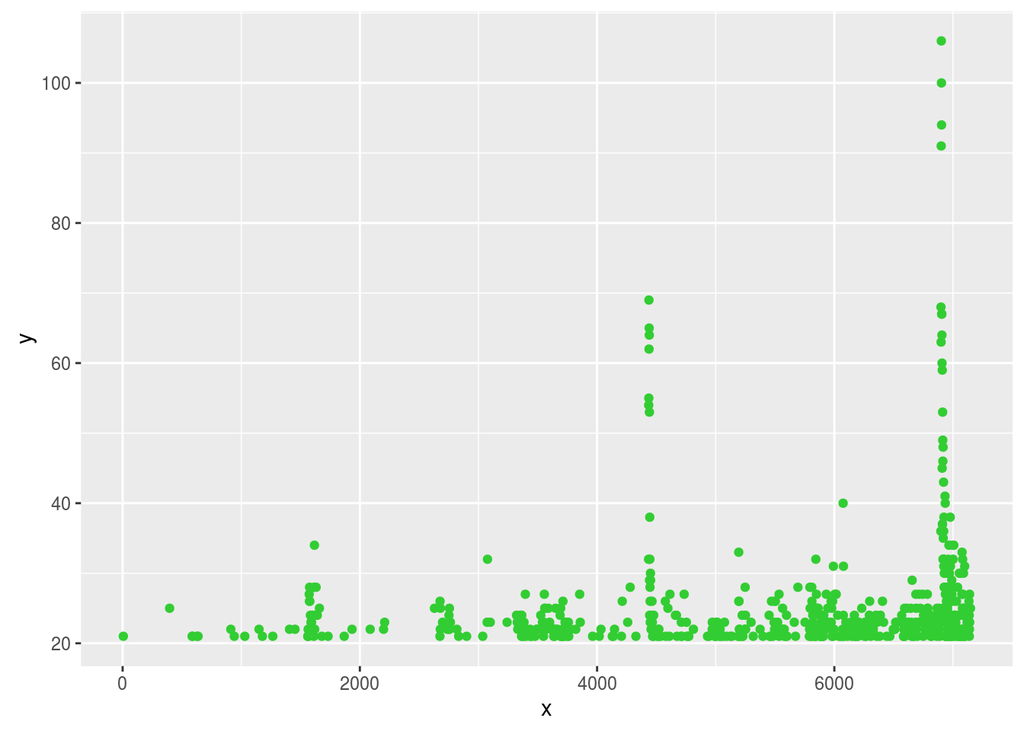

```r
czas<-dane[,6]
licznosci<-table(czas)
punkty<-matrix(0,nrow=length(licznosci),ncol=2)
punkty[,1]<-table(czas)
punkty[,2]<-seq(1,length(licznosci))
colnames(punkty)<-c("y","x")
punkty2<-as.data.frame(punkty)

ggplot(punkty2[punkty2[,1]>20,],aes(x=x,y=y))+
   geom_point(col="limegreen",show.legend = FALSE)
```

```r
(licznosci[6900])
```

```
## 2016-02-28 23:55:49
##                  63
```

Zobaczmy jeszcze na liczbę tweet’ów, które nie były retweet’owane, wstawianych co sekundę.

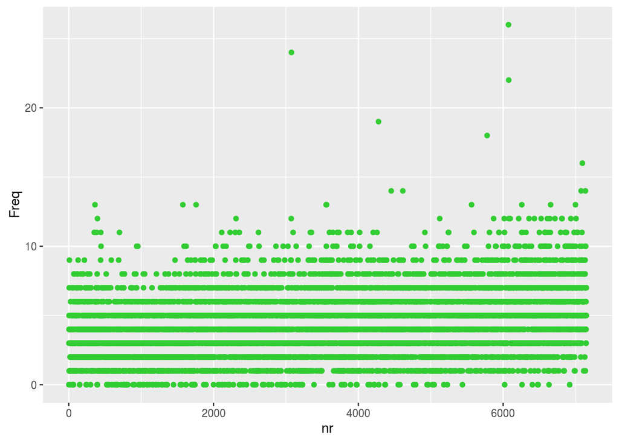

```r
dane2<-dane[dane[,14]==FALSE,]
czas2<-dane2[,6]
licznosci2<-table(czas2)
punkt3<-as.data.frame(licznosci2)
nr<-seq(1,length(licznosci2))
punkt4<-cbind(punkt3,nr)

ggplot(punkt4,aes(x=nr,y=Freq))+
   geom_point(col="limegreen",show.legend = FALSE)
```

Widać, że dwa piki, które były widoczne na poprzednim wykresie zniknęły. Po przejrzeniu danych okazało się, że były to dwa tweet’y o bardzo dużej liczbie retweet’owań (i oczywiśćie dotyczyły Leo).

```r
as.character(dane[55489,2])
```

```
## [1] "RT @epDannyEdge: Leo. Has. To. Win. His. Oscar."
```

```r
as.character(dane[96875,2])
```

```
## [1] "RT @pewdiepie: I hope I wake up to Leo winning an Oscar"
```